# APTS Design of Studies - Practical 2 Example Solutions

September 2021

Dave Woods (D.Woods@southampton.ac.uk ; http://www.southampton.ac.uk/~davew) Statistical Sciences Research Institute, University of Southampton

**Computer experiments**  
We start by generating a maximin Latin hypercube, following the run of thumb of having 10 times as many runs as input variables. The function `maximinSA_LHS` requires a starting design for the optimisation; we will use a random Latin hypercube of the correct size. We can visualise our final design by looking at one-dimensional projections (which should be uniform) and two-dimensional projections (the design criterion doesn’t consider these, but they hopefully will look OK).

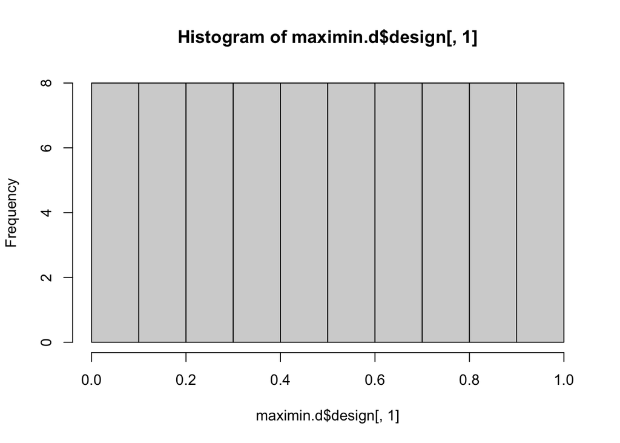

```r
library(DiceDesign)
start.design <- lhsDesign(80, 8)$design
maximin.d <- maximinSA_LHS(start.design)
colnames(maximin.d$design) <- c("rw", "r", "Tu", "Hu", "Tl", "Hl", "L", "Kw")
hist(maximin.d$design[, 1])
```

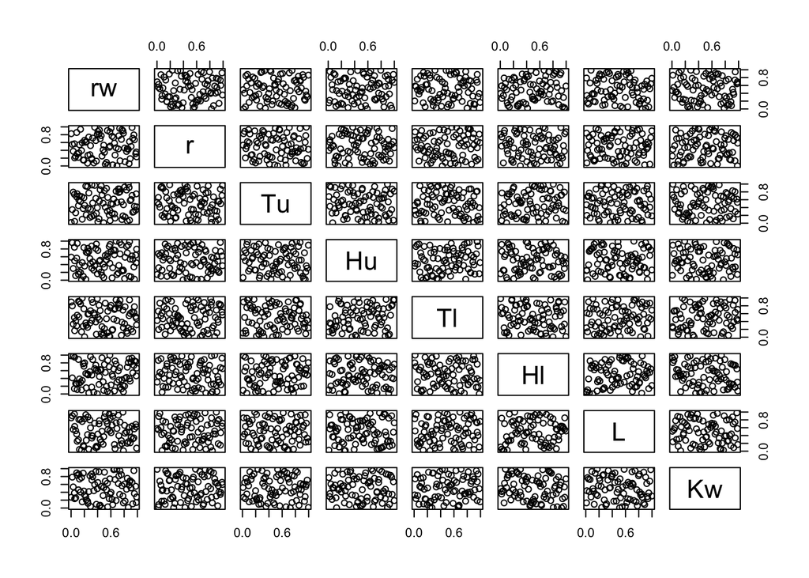

```r
pairs(maximin.d$design)
```

To run the experiment, we need to scale our design to the appropriate ranges (`DiceDesign` finds designs on the scale $[0,1]$) and pass each row of the design to the `borehole` function.

```r
library(apts.doe)
l <- c(.05, 100, 63070, 990, 63.1, 700, 1120, 9855)
u <- c(.15, 50000, 115600, 1110, 116, 820, 1680, 12045)
center <- -l / (u - l)
scalev <- 1 / (u - l)
bhdesign <- scale(maximin.d$design, center = center, scale = scalev)
bhdesign
```

```
##               rw          r        Tu        Hu        Tl       Hl        L
##  [1,] 0.11537239 29219.0282  75382.12 1068.3173 100.50402 709.3176 1215.375
##  [2,] 0.14546237 33514.5571  85695.92  993.0483 104.21359 801.9650 1439.911
##  [3,] 0.05535548 10359.4135  65444.77 1049.6694  71.83889 813.4733 1474.682
##  [4,] 0.12662909 46364.5476  67959.53 1018.0191  83.26376 744.0609 1226.499
##  [5,] 0.14826760 17918.0545 102395.51 1043.3945  88.60545 755.9380 1466.979
##  [6,] 0.07673155 37013.2550 103611.68 1078.5740  94.62532 703.0235 1149.465
##  [7,] 0.13140425  5431.1244  71252.47 1060.4337 104.08928 748.3192 1377.999
##  [8,] 0.09267319 45991.7186  92676.63 1048.3820  86.82722 753.9493 1556.455
##  [9,] 0.06828096  7684.0230  82597.72 1001.8662  77.86824 793.1268 1199.162
## [10,] 0.10024538 17454.0793 106630.97 1029.5972  74.62280 791.0753 1610.302
## [11,] 0.10745694 23907.8701  74227.83 1093.4344  64.56479 784.1258 1645.538
## [12,] 0.14046010 25035.2237  94832.93 1000.0361  73.79977 798.8818 1320.860
## [13,] 0.12378778  6696.8456 105347.17 1070.7515 112.68672 720.7161 1536.508
## [14,] 0.08256554 35750.2627  90150.01 1046.2768 109.84955 806.0497 1335.705
```

[output cut: 153 more lines]

```r
y <- apply(bhdesign, 1, borehole)
y
```

```
##  [1] 147.24706  93.16504  15.96210 123.48550 136.12401  64.82985 124.97501
##  [8]  50.70603  29.96537  55.07848  70.27019 102.17133 130.05917  44.49503
## [15]  66.14203 100.00442  71.93234  12.61441  76.92288 116.53137  60.55221
## [22] 103.05302 173.32664  20.32551  14.32303 135.26979 107.86412  38.26139
## [29] 143.42115  48.49855 188.62181 174.35139  24.58111 132.77665  43.09265
## [36]  72.86306  89.48699  89.90764  23.00756  47.87238  78.59548  61.47283
## [43]  39.59209  35.82351  67.27342 142.10412  71.87257  67.45110 145.10412
## [50]  65.57051  39.53133  25.26330  36.88517  98.24134 117.35111 136.60791
## [57]  21.34307  92.89031 148.23353  20.03475  30.25394  75.83410  41.12257
## [64]  59.01433 173.69731  30.40927  66.08662  64.67514  41.75676 121.48120
## [71]  66.94430  27.87099 152.65194  63.77259  23.92452  67.12967  41.35870
## [78]  24.49958  94.93653  86.83445
```

We use `DiceKriging` and the `km` function to fit a GP model to this data. We use our original design on the interval $[0,1]$ so that the correlation parameters are comparable (they are all on the same scale).

```r
library(DiceKriging)
gp <- km(formula = ~., design = maximin.d$design, response = y, control = list(trace = F))
gp
```

```
##
## Call:
## km(formula = ~., design = maximin.d$design, response = y, control = list(trace = F))
##
## Trend  coeff.:
##                Estimate
##  (Intercept)    21.8785
##           rw   144.1632
##            r     0.8479
##           Tu    -1.8313
##           Hu    35.0752
##           Tl     1.6642
##           Hl   -30.1165
##            L   -32.6835
##           Kw    14.6344
##
## Covar. type  : matern5_2
## Covar. coeff.:
##                Estimate
##    theta(rw)     0.4887
##     theta(r)     1.9782
##    theta(Tu)     1.9749
##    theta(Hu)     1.4027
##    theta(Tl)     1.9694
##    theta(Hl)     1.4490
##     theta(L)     1.1735
##    theta(Kw)     1.9644
##
## Variance estimate: 163.1625
```

The dominant variable is $r_w$, with a large linear coefficient and a small $\theta$ (correlation parameter).

We can graphically explore a bit using leave-one-out predictions. If we plot these against the response, we would hope to see a line close to the diagonal, with narrow intervals mostly crossing the line (so the response is usually within the interval). We can also work out an approximate $R^2$ value as the square of the correlation between the response and the mean prediction. The model looks pretty good on these measures.

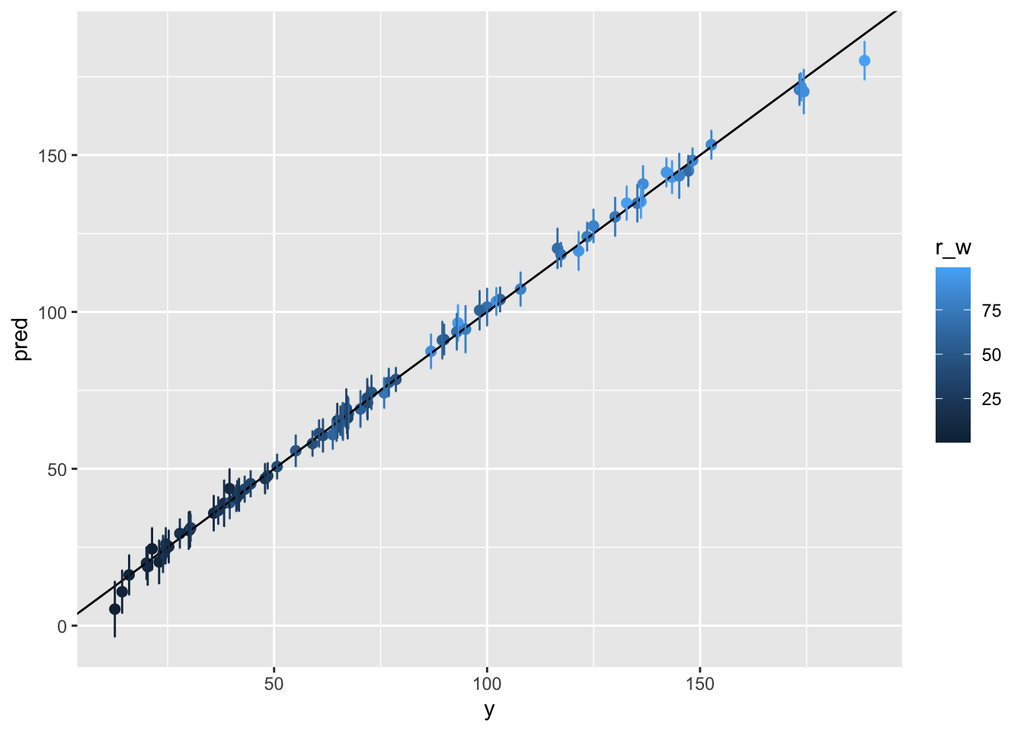

```r
library(ggplot2)
loo <- leaveOneOut.km(gp, type = "UK", trend.reestim = T)
summary_df <- data.frame(y = y, pred = loo$mean, ymin = loo$mean - 2 * loo$sd, ymax = loo$mean + 2 * loo$sd)
ggplot(summary_df, aes(x = y, y = pred, color = 100 * maximin.d$design[, "rw"])) + geom_point(size = 2) +
  geom_abline(slope = 1, intercept = 0) +
  geom_errorbar(aes(ymin = ymin, ymax = ymax)) + labs(color = "r_w")
```

```r
with(summary_df, cor(y, pred)) ^ 2
```

```
## [1] 0.9979813
```